# Exercises for Introduction to Bayesian analysis

Benjamin Skov Kaas-Hansen

2023-05-10

## To do for 2024 version of the course

- Part A of exercises needs to be a lot shorter
- Remove everything about simple sampling from slide deck and exercises
- Go straight to using stan instead
- Need to explain MCMC sampling in simple terms, with 1- og 2D PDF
- Consider making e.g. Shiny that produces “community-prior values” for both proportion and continuous variables

All of these exercises use the R program package. We will be needing a few packages (all on CRAN). You can install these with the `install.packages()` function:

```r
install.packages(c(
  "rstan", "rstanarm", "bayesplot", "coda",
  "dplyr", "ggplot2", "purrr",
  "adaptr"
))
```

```r
for (p in c("dplyr", "ggplot2", "purrr", "adaptr", "coda")) {
  library(p, character.only = TRUE)
}
```

The exercises revolve around two types of problems: introductory code that you should run through to make sure you understand how to use the function(s) and interpret the output, and additional questions to explore and discuss to dig a bit deeper into Bayesian data analysis and inference.

## A. Bayesian analysis “by hand”

In this exercise we will take the example with the ICU patients from the lecture and investigate what happens to the conclusions from a Bayesian analysis when we modify the prior and have more observations. This will also address why the straight-forward sampling approach might not be sufficiently efficient and why specialised software would be needed.

1. Run the code below and make sure you understand what is going on in each line

   ```r
   n_samples <- 10000
   n_obs <- 22
   n_women <- 8

   theta <- runif(n_samples)
   cond_likelihood_draws <- rbinom(n_samples, size = n_obs, prob = theta)
   posterior_draws <- theta[cond_likelihood_draws == n_women]
   ```

2. Plot a histogram of the posterior draws of theta (i.e. theta values you have kept because they gave rise to an outcome matching our original outcome)

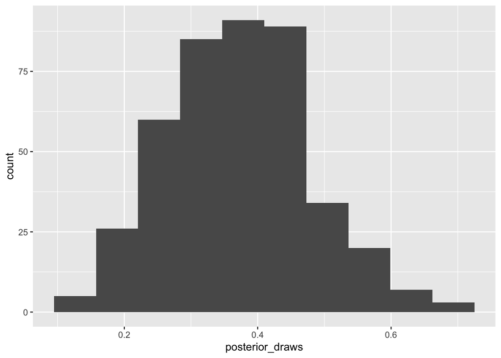

   ```r
   ggplot() +
     geom_histogram(aes(posterior_draws), bins = 10)
   ```

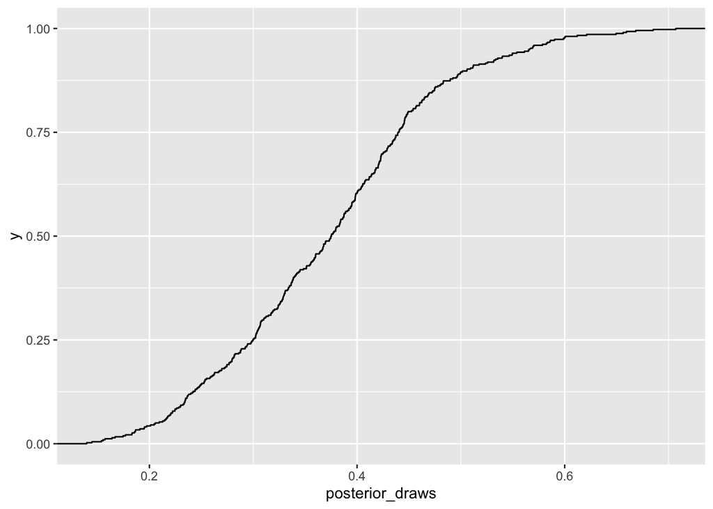

   ```r
   ggplot() +
     stat_ecdf(aes(posterior_draws))
   ```

3. Compute the median and 95% CrI of the posterior; provide a guess of the MAP
   - Hint: R doesn’t have a built-in function for finding the mode of a distribution

   ```r
   dist_mode <- function(x, ...) { # ... passed on to density()
     with(density(x, ...), x[which.max(y)])
   }

   dist_mode_bad <- function(x, n_digits = 2) { # helper function; finds mode of x
       x <- round(x, n_digits)
       ux <- unique(x)
       ux[which.max(tabulate(match(x, ux)))][1] # index in case of ties
   }

   median(posterior_draws)
   ```

   ```
   ## [1] 0.3750848
   ```

   ```r
   quantile(posterior_draws, c(0.025, 0.5, 0.975))
   ```

   ```
   ##      2.5%       50%     97.5%
   ## 0.1844307 0.3750848 0.5947315
   ```

   ```r
   dist_mode(posterior_draws)
   ```

   ```
   ## [1] 0.4052995
   ```

4. Now use a non-uniform distribution
   - Hint: you are free to pick any non-uniform distribution that yields only values between 0 and 1; after all, it’s a prior over a proportion (which can be neither below 0 nor above 1)
   - Hint: a beta distribution could be interesting. Use the `rbeta()` function and select some interesting shape parameters that would express realistic prior expectations about the distribution between women and men

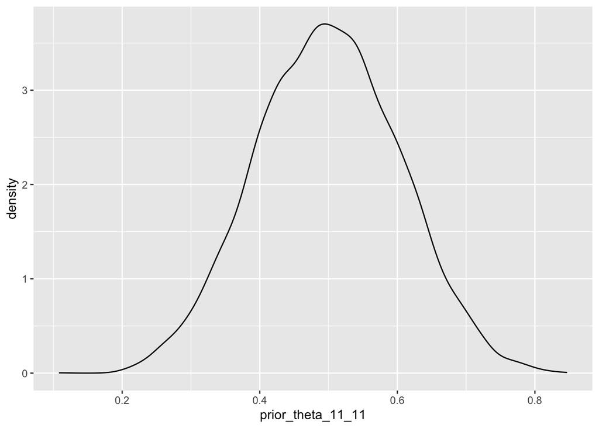

   ```r
   posterior_theta <- function(a, b, N = n_obs, z = n_women) {
       theta <- rbeta(n_samples, a, b)
       cond_likelihood_draws <- rbinom(n_samples, size = N, prob = theta)
       return(theta[z == cond_likelihood_draws])
   }

   prior_theta_11_11 <- rbeta(n_samples, 11, 11)
   ggplot() +
      geom_density(aes(prior_theta_11_11))
   ```

   ```r
   post_theta_11_11 <- posterior_theta(11, 11)
   ```

5. Visualise the prior distribution
   - Hint: this can be done with e.g. histograms, density plots and empirical cumulative density plots

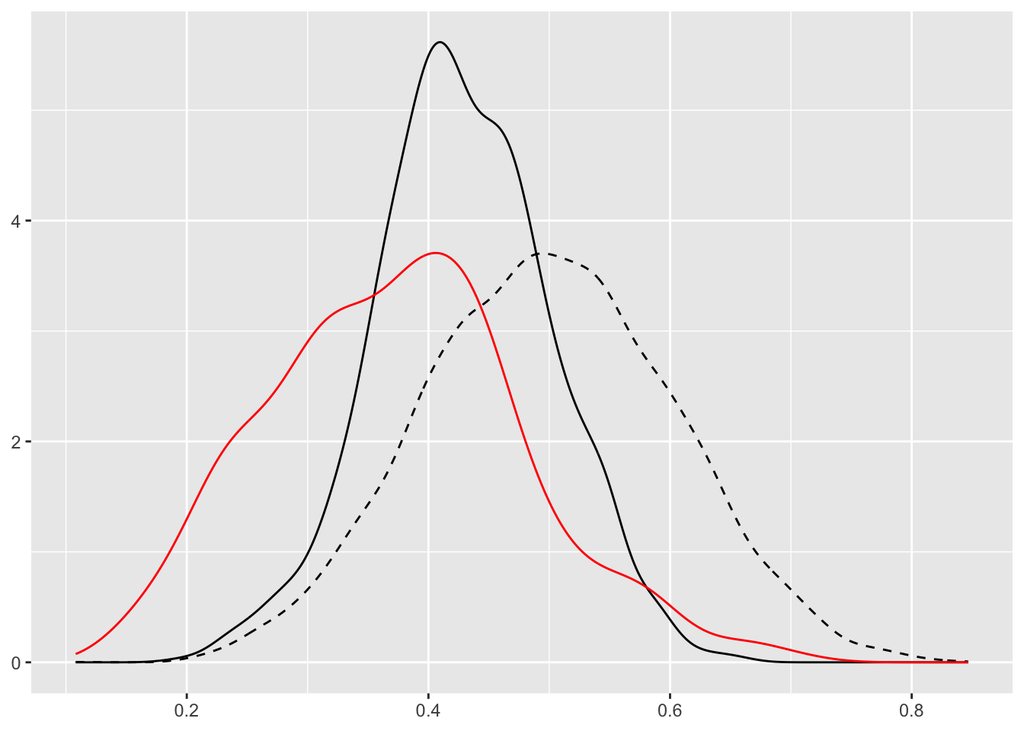

   ```r
   ggplot() +
     stat_density(aes(x = prior_theta_11_11), geom = "line", linetype = 2) +
     stat_density(aes(x = post_theta_11_11), geom = "line") +
     stat_density(aes(x = posterior_draws), geom = "line", colour = "red") +
     labs(x = NULL, y = NULL)
   ```

6. Repeat the analysis from point 1 above with the new prior. Plot the posterior distribution, and compute the MAP and median posterior value.

   ```r
   # plot: see above
   median(post_theta_11_11)
   ```

   ```
   ## [1] 0.4255311
   ```

   ```r
   dist_mode(post_theta_11_11)
   ```

   ```
   ## [1] 0.4094077
   ```

7. Conclude on your analysis with words

8. How did the results with your own prior change compared to the initial analysis? Why?
9. How many thetas are part of the posterior distribution? How does that compare to `n_samples`? What is the problem here?
   - Hint: try to rerun the analysis a few times, computing each time the median and 95% CrI. Then, compare these summary statistics across runs.

   ```r
   length(post_theta_11_11)
   ```

   ```
   ## [1] 841
   ```

   ```r
   length(post_theta_11_11) / n_samples
   ```

   ```
   ## [1] 0.0841
   ```

   ```r
   map_dfr(1:10, ~ quantile(posterior_theta(11, 11), c(0.025, 0.5, 0.975)))
   ```

   ```
   ## # A tibble: 10 × 3
   ##    `2.5%` `50%` `97.5%`
   ##     <dbl> <dbl>   <dbl>
   ##  1  0.290 0.432   0.575
   ##  2  0.286 0.429   0.576
   ##  3  0.290 0.430   0.572
   ##  4  0.290 0.428   0.577
   ##  5  0.298 0.429   0.579
   ##  6  0.289 0.428   0.572
   ##  7  0.290 0.433   0.573
   ##  8  0.303 0.437   0.581
   ##  9  0.293 0.427   0.570
   ## 10  0.304 0.439   0.579
   ```

10. Give a rule a thumb as to the number of effective samples (i.e. those prior samples giving rise to the observed outcome) you need to obtain stable results.
    - Hint: first define “stable results”, e.g. how much the bounds of the 95% CrI may change across runs.
11. Now assume that we had had 10 ICUs (all with 22 beds) but with the same distribution between sexes (i.e. `n_obs <- 220` and `n_women <- 80`). Rerun the analysis with your own prior and compare the results from this larger dataset to the previous analysis. How are they similar? How are they different?

    ```r
    # Data clearly dominate the prior

    posterior_draws_large <- posterior_theta(11, 11, 220, 80)
    posterior_draws_large_11_11 <- posterior_theta(110, 110, 220, 80)


    median(post_theta_11_11)
    ```

    ```
    ## [1] 0.4255311
    ```

    ```r
    median(posterior_draws_large)
    ```

    ```
    ## [1] 0.3778591
    ```

    ```r
    dist_mode(post_theta_11_11)
    ```

    ```
    ## [1] 0.4094077
    ```

    ```r
    dist_mode(posterior_draws_large)
    ```

    ```
    ## [1] 0.3697699
    ```

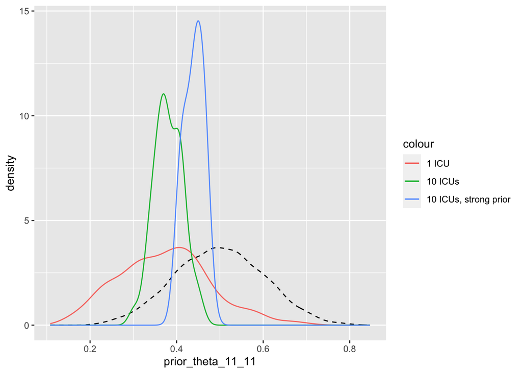

    ```r
    ggplot() +
      stat_density(aes(x = prior_theta_11_11), geom = "line", linetype = 2) +
      stat_density(aes(posterior_draws, colour = "1 ICU"), geom = "line") +
      stat_density(aes(posterior_draws_large, colour = "10 ICUs"), geom = "line")  +
      stat_density(aes(posterior_draws_large_11_11, colour = "10 ICUs, strong prior"), geom = "line")
    ```

12. Reusing the posterior samples from exercise A6, find the percentile 95% CrI of the posterior distribution using `quantile()`. Then, compute also the 95% highest posterior density interval (HPDI) and comment on any differences that may emerge.
    - Hint: convert first to an `mcmc` object (the `coda` package has the functions to do this)
    - Hint: try to plot the distribution of the posterior samples and draw both the percentile CrI and the HPDI.

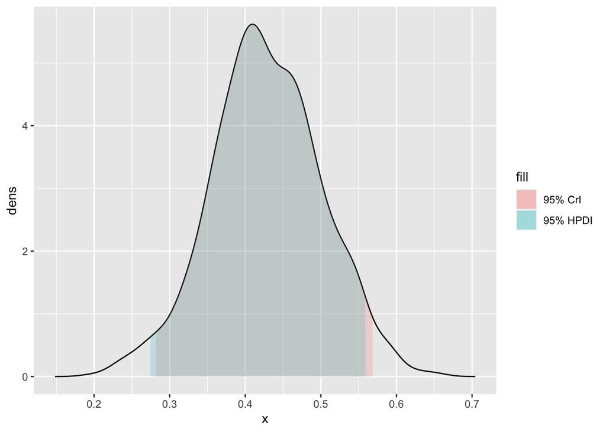

    ```r
    cri <- quantile(post_theta_11_11, c(0.025, 0.975))
    hpdi <- HPDinterval(as.mcmc(post_theta_11_11), prob = 0.95)

    plot_df <- with(density(post_theta_11_11), tibble(x, dens = y)) %>%
      mutate(
        in_95cri = between(x, cri[1], cri[2]),
        in_95hpdi = between(x, hpdi[1], hpdi[2])
      )

    ggplot(plot_df, aes(x = x, y = dens)) +
      geom_line() +
      geom_area(aes(fill = "95% CrI"), ~ filter(., in_95cri), alpha = 0.2) +
      geom_area(aes(fill = "95% HPDI"), ~ filter(., in_95hpdi), alpha = 0.2)
    ```

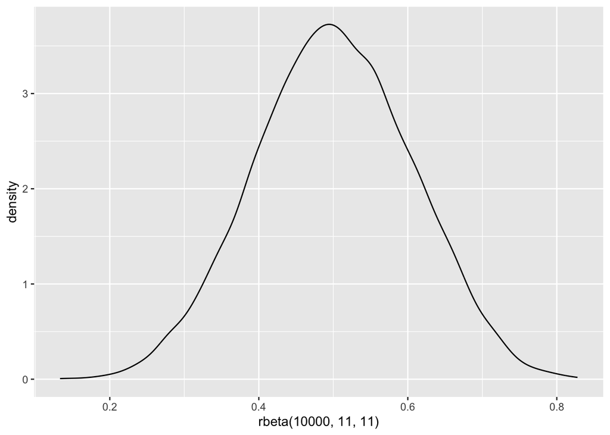

    ```r
    ggplot() +
      geom_density(aes(rbeta(10000, 11, 11)))
    ```

## B. Devising and using priors

1. Expecting an in-ICU mortality risk of 20% in patients with septic shock, devise a couple of priors that express this expectation with multiple levels of certainty. Compute the median and 95% interval
   - Hint: you can (but don’t have to!) use `find_beta_params()` from the `adaptr` package

   ```r
   map_dfr(c(0.025, 0.05, 0.1), ~ find_beta_params(0.2, ., n_dec = 2))
   ```

   ```
   ##   alpha  beta       p2.5     p50.0     p97.5
   ## 1  1.85  7.41 0.02490928 0.1777423 0.4937889
   ## 2  3.22 12.88 0.04998349 0.1874077 0.4197214
   ## 3  9.43 37.71 0.10003411 0.1957777 0.3240885
   ```

2. Devise priors with the same levels of certainty but with other in-ICU mortality risks

   ```r
   expand.grid(theta = c(0.15, 0.2, 0.25), boundary = c(0.025, 0.05, 0.1)) %>%
     bind_cols(with(., map2_dfr(theta, boundary, find_beta_params, n_dec = 2)))
   ```

   ```
   ##   theta boundary alpha   beta       p2.5     p50.0     p97.5
   ## 1  0.15    0.025  2.32  13.14 0.02502351 0.1348900 0.3588380
   ## 2  0.20    0.025  1.85   7.41 0.02490928 0.1777423 0.4937889
   ## 3  0.25    0.025  1.59   4.76 0.02519434 0.2231835 0.6188157
   ## 4  0.15    0.050  4.70  26.66 0.04992283 0.1423983 0.2917302
   ## 5  0.20    0.050  3.22  12.88 0.04998349 0.1874077 0.4197214
   ## 6  0.25    0.050  2.53   7.59 0.05000309 0.2330860 0.5420524
   ## 7  0.15    0.100 24.89 141.04 0.10000338 0.1485954 0.2079829
   ## 8  0.20    0.100  9.43  37.71 0.10003411 0.1957777 0.3240885
   ## 9  0.25    0.100  5.77  17.31 0.09999493 0.2426845 0.4408792
   ```

3. Assume that you are working at a production facility with quality control of a novel drug miraculixaban. You want to estimate the probability of producing a faulty batch in the coming year. In the previous year 365 batches were produced; none were faulty.

   Estimate the probability of faulty batch based on a frequentist analysis of the data. What is your estimated proportion? What is your forecast of faulty batches for the coming year? Can any happen?
   - Hint: the maximum likelihood estimate of a binomial variable with $k$ successes (here, faulty batches) in $N$ trials (here, days in a year) is $\hat \theta = \tfrac{k}{N}$
   - Hint: recall the definitions of probability from the slides

   ```r
   #' The maximum likelihood estimator theta (MLE) of a binomial variable with
   #' k successes in n k/n. Because k=0, the MLE is zero, leaving no uncertainty,
   #' and so there’s no standard error, making it impossible to actually derive
   #' a confidence interval. So the forecast would be 0 failures.
   ```

4. Use a Bayesian modeling approach to estimate the probability of a faulty batch for the coming year. How/why can the conclusion change? Which result is more reasonable?
   - Hint: which prior is conjugate to a binomial likelihood (which is what we have here)?

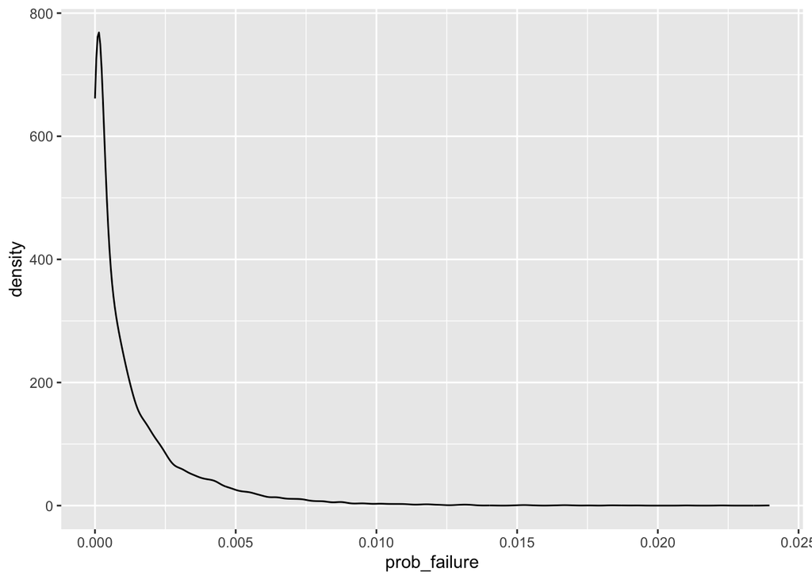

   ```r
   #' For a beta(a, b) prior and a binomial(n, theta) likelihood, the posterior is
   #' beta(a + k, b + n - k), because the beta distribution is a conjugate prior
   #' to the binomial likelihood. Thus, prop_failure is the posterior
   #' distribution of the expected probability of producing a failed drug,
   #' assuming a beta(0.5, 0.5) prior (Jeffrey’s prior).

   prob_failure <- rbeta(10000, 0.5 + 0, 0.5 + 365)
   ggplot() + geom_density(aes(prob_failure), trim = TRUE)
   ```

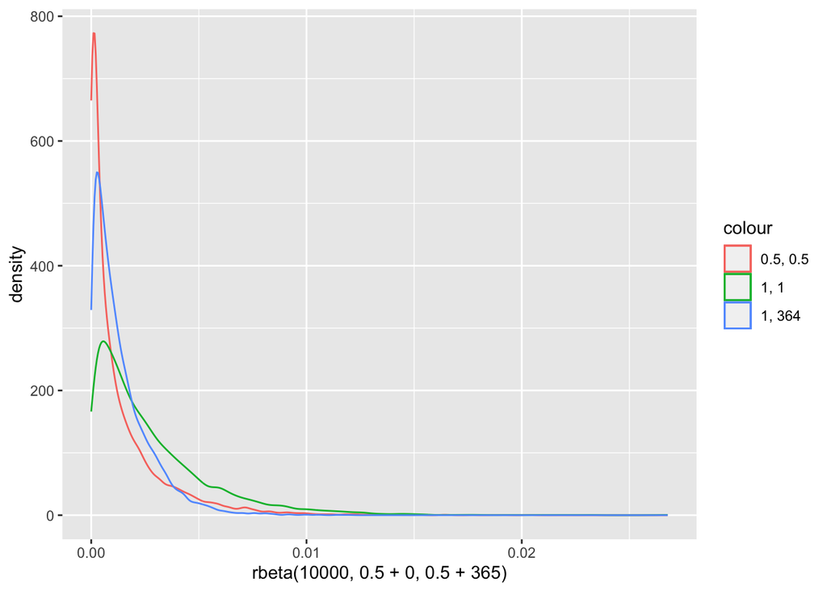

   ```r
   ggplot() +
     geom_density(aes(rbeta(10000, 0.5 + 0, 0.5 + 365), colour = "0.5, 0.5")) +
     geom_density(aes(rbeta(10000, 1 + 0, 1 + 365), colour = "1, 1")) +
     geom_density(aes(rbeta(10000, 1 + 0, 364 + 365), colour = "1, 364"))
   ```

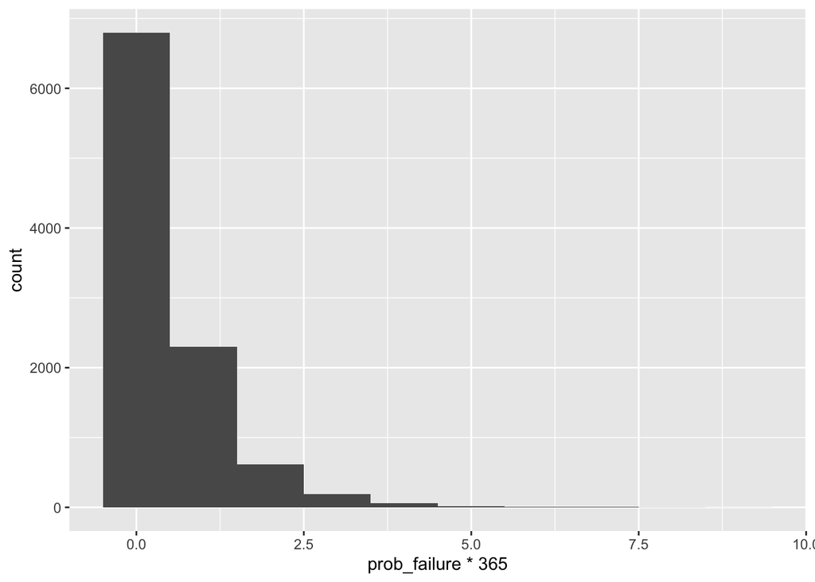

   ```r
   # Distribution of the expected number of faults with 365 batches produced:
   ggplot() + geom_histogram(aes(prob_failure * 365), binwidth = 1)
   ```

5. Imagine you know 10 experts with experience in the same type of production line as your factory. You would like to survey these experts and use their responses to devise an appropriate prior for the annual fault probability. How would you go about that?

   ```r
   #' One could ask them to give the number of faulty batches out of 365
   #' produced. Then, one could compute the pooled proportion and "rescale"
   #' to arrive at a 365-day time frame. For example:

   survey_responses <- c(1, 1, 0, 0, 2, 1, 2, 1, 1, 0)
   mean(survey_responses)
   ```

   ```
   ## [1] 0.9
   ```

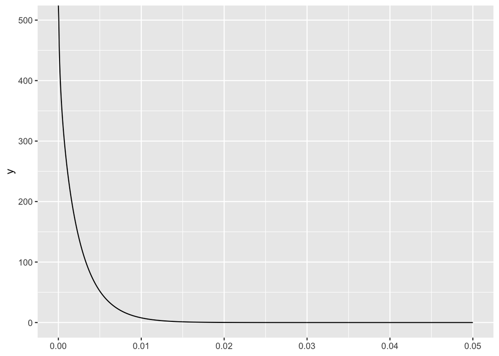

   ```r
   ggplot() +
     stat_function(fun = ~ dbeta(., 0.9, 365 - 0.9), n = 1000, xlim = c(0, 0.05))
   ```

## C. Using rstanarm

We will now perform the same analysis as we did above but using the `rstanarm` package. We will start by loading the relevant package and create a dataset that can be used for logistic regression.

```r
library("rstanarm")
library("bayesplot")
dta <- data.frame(woman = rep(0:1, times = c(22 - 8, 8)))
```

1. Use the `stan_glm()` function to fit a logistic model. Remember that a logistic model fits parameters on the log-odds (= logit) scale.
   - Hint: remember to set `family = binomial` to run a logistic regression
   - Hint: to fit a regression model without covariates, the formula should have the form `y ~ 1` where `y` is the outcome variable in the data.

```r
fit <- stan_glm(
  woman ~ 1,
  data = dta,
  family = binomial,
  cores = 1,
  refresh = 0 # just to suppress sampler output (avoids cluttering
)
```

2. Extract the posterior values and plot the posterior distribution of the intercept.
   - Hint: use `as.matrix()` and `mcmc_areas()`

```r
posteriors <- as.matrix(fit)
as_tibble(fit)
```

[output not shown]

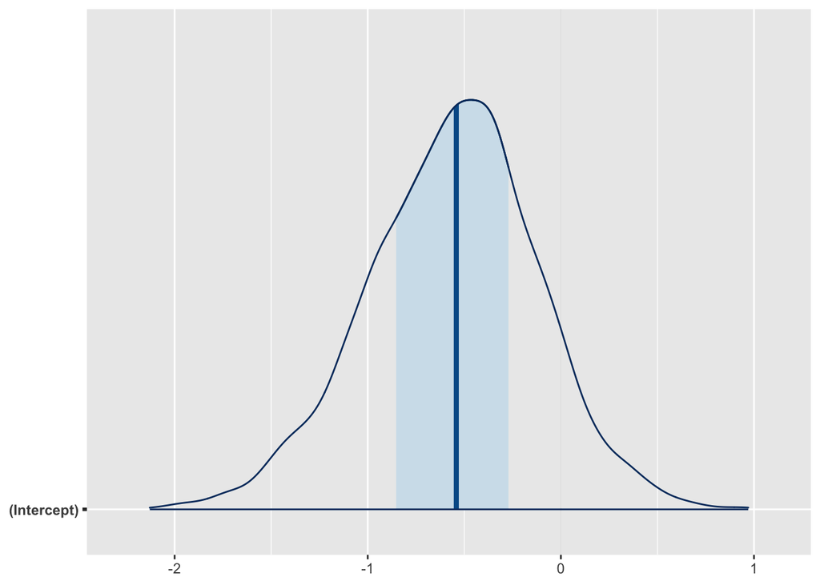

```r
mcmc_areas(posteriors)
```

3. Compute the MAP and median posterior on the probability scale.
   - Hint: recall that $g(x) = \frac{\exp(x)}{1 + \exp(x)}$ is the inverse function to the logistic transform
   - Hint: look at `?posterior_epred`

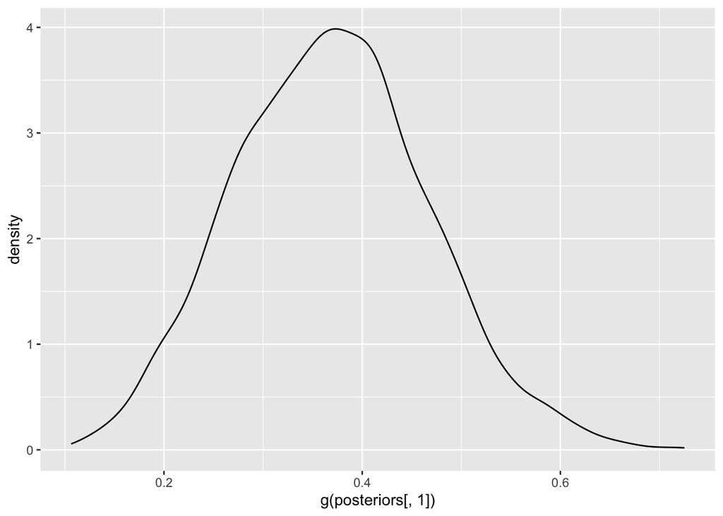

   ```r
   g <- function(logit) {
     exp(logit) / (1 + exp(logit))
   }

   ggplot() +
     geom_density(aes(g(posteriors[, 1])))
   ```

4. `stan_glm()` uses a zero-mean normal distribution as prior for the intercept by default. Thus, we might not get the same posterior distribution as we did above. How could we modify the prior distribution to make it resemble a uniform distribution? Try to refit the model with this uniform distribution
   - Hint: look at `?stan_glm` and https://mc-stan.org/rstanarm/articles/priors.html

   ```r
   fit_uniform_prior <- stan_glm(
     woman ~ 1,
     data = dta,
     family = binomial,
     prior_intercept = NULL, # uses uniform prior
     cores = 1,
     refresh = 0 # just to suppress sampler output (avoids cluttering
   )
   ```

5. Try to change the prior distribution to e.g. `normal(0.0, 0.1)` and rerun the analysis. How does this impact the conclusion? Why?

   ```r
   fit_normal_prior <- stan_glm(
     woman ~ 1,
     data = dta,
     family = binomial,
     prior_intercept = normal(0.0, 0.1),
     cores = 1,
     refresh = 0 # just to suppress sampler output (avoids cluttering)
   )
   ```

6. Try your own prior and see how it influences the result.

   ```r
   #' Same as above but using whatever prior you used
   ```

7. Prior predictive checks are like posterior predictive checks, only that they ignore the data and generates data based solely on the priors. This can often be useful to check that the priors you have specified will yield data that look reasonable for the modelling task at hand. Carry out a prior predictive check of the three models above (default prior, `normal(0.0, 0.1)` and your own). All good?
   - Hint: see the `prior_PD` argument in `?stan_glm`.

   ```r
   # Create new larger dataset
   update(fit, prior_PD = TRUE)
   ```

   ```
   ## stan_glm
   ##  family:       binomial [logit]
   ##  formula:      woman ~ 1
   ##  observations: 22
   ##  predictors:   1
   ## ------
   ##             Median MAD_SD
   ## (Intercept) -0.1    2.4
   ##
   ## ------
   ## * For help interpreting the printed output see ?print.stanreg
   ## * For info on the priors used see ?prior_summary.stanreg
   ```

8. Now assume, again, that we had had data from 10 ICUs (as above). Construct a new data frame akin to the one above but with more observations. Then, rerun the analysis with your own prior and compare the results from this larger dataset to those of the previous analysis. How are they similar? How do they differ?

   ```r
   # Create new larger dataset
   dta_large <- data.frame(woman = rep(0:1, times = c(220 - 80, 80)))

   fit_large <- update(fit, data = dta_large) # do the same with the other fits
   summary(fit_large)
   ```

   ```
   ##
   ## Model Info:
   ##  function:     stan_glm
   ##  family:       binomial [logit]
   ##  formula:      woman ~ 1
   ##  algorithm:    sampling
   ##  sample:       4000 (posterior sample size)
   ##  priors:       see help('prior_summary')
   ##  observations: 220
   ##  predictors:   1
   ##
   ## Estimates:
   ##               mean   sd   10%   50%   90%
   ## (Intercept) -0.6    0.1 -0.8  -0.6  -0.4
   ##
   ## Fit Diagnostics:
   ##            mean   sd   10%   50%   90%
   ## mean_PPD 0.4    0.0  0.3   0.4   0.4
   ##
   ## The mean_ppd is the sample average posterior predictive distribution of the outcome variable (for details see help('summary.stanreg')).
   ##
   ## MCMC diagnostics
   ##               mcse Rhat n_eff
   ## (Intercept)   0.0  1.0   947
   ## mean_PPD      0.0  1.0  1355
   ## log-posterior 0.0  1.0   700
   ##
   ## For each parameter, mcse is Monte Carlo standard error, n_eff is a crude measure of effective sample size, and Rhat is the potential scale reduction factor on split chains (at convergence Rhat=1).
   ```

## D. Multiple linear regression

In this exercise we will use data from a fictive RCT with ICU patients randomised to miraculixaban (`treatment = 1`) vs. standard of care (`treatment = 0`) . The dataset also contains a few baseline covariates (`age,` `woman` and `sepsis`) along with outcome variables (`icu_los`, `hosp_los` and `dead_at_1y`).

Download the data and take a look:

```r
icu <- read.delim("https://raw.githubusercontent.com/epiben/course_adv_stats_ucph/main/bayesian/icu.tsv")
head(icu)
```

```
##   id treatment age woman sepsis icu_los hosp_los dead_at_1y
## 1  1         0  74     1      1    1.69     5.64          1
## 2  2         0  62     1      0   11.82    54.12          1
## 3  3         0  21     1      1   13.75    48.53          0
## 4  4         0  44     1      1   18.05    57.66          0
## 5  5         0  62     1      1    0.34     1.51          1
## 6  6         1  74     1      1    2.93    12.57          1
```

1. Analyse the data with a regular frequentist model, estimating the effect of relevant covariates on the ICU length of stay. Ignore the `treatment` covariate for now. What are your overall conclusions? What are your conclusions about the impact of sepsis on ICU length-of-stay?
   - Hint: relevant covariates should not contain information about the future

   ```r
   freq_fit <- lm(icu_los ~ age + sepsis + woman, data = icu)
   summary(freq_fit)
   ```

   ```
   ##
   ## Call:
   ## lm(formula = icu_los ~ age + sepsis + woman, data = icu)
   ##
   ## Residuals:
   ##    Min     1Q Median     3Q    Max
   ## -22.48 -18.12 -13.05  -0.03 338.19
   ##
   ## Coefficients:
   ##             Estimate Std. Error t value Pr(>|t|)
   ## (Intercept) 23.62306    3.89321   6.068 1.84e-09 ***
   ## age         -0.04298    0.06370  -0.675    0.500
   ## sepsis      -1.23795    2.57159  -0.481    0.630
   ## woman        0.05376    2.59385   0.021    0.983
   ## ---
   ## Signif. codes:  0 '***' 0.001 '**' 0.01 '*' 0.05 '.' 0.1 ' ' 1
   ##
   ## Residual standard error: 39.28 on 994 degrees of freedom
   ## Multiple R-squared:  0.0006794,  Adjusted R-squared:  -0.002337
   ## F-statistic: 0.2252 on 3 and 994 DF,  p-value: 0.8789
   ```

2. Analyse the same model using a Bayesian analysis with the `stan_glm()` function. Try to specify reasonable priors

   ```r
   bayes_fit <- stan_glm(
     icu_los ~ age + sepsis + woman,
     data = icu,
     seed = 4131,
     refresh = 0
   )

   summary(bayes_fit)
   ```

   ```
   ##
   ## Model Info:
   ##  function:     stan_glm
   ##  family:       gaussian [identity]
   ##  formula:      icu_los ~ age + sepsis + woman
   ##  algorithm:    sampling
   ##  sample:       4000 (posterior sample size)
   ##  priors:       see help('prior_summary')
   ##  observations: 998
   ##  predictors:   4
   ##
   ## Estimates:
   ##               mean   sd   10%   50%   90%
   ## (Intercept) 23.6    3.9 18.6  23.5  28.6
   ## age          0.0    0.1 -0.1   0.0   0.0
   ## sepsis      -1.3    2.6 -4.6  -1.3   2.1
   ## woman        0.1    2.6 -3.2   0.1   3.4
   ## sigma       39.3    0.9 38.2  39.3  40.4
   ##
   ## Fit Diagnostics:
   ##            mean   sd   10%   50%   90%
   ## mean_PPD 20.7    1.8 18.5  20.7  23.0
   ##
   ## The mean_ppd is the sample average posterior predictive distribution of the outcome variable (for details see help('summary.stanreg')).
   ##
   ## MCMC diagnostics
   ##               mcse Rhat n_eff
   ## (Intercept)   0.1  1.0  5692
   ## age           0.0  1.0  6092
   ## sepsis        0.0  1.0  5721
   ## woman         0.0  1.0  5333
   ## sigma         0.0  1.0  5639
   ## mean_PPD      0.0  1.0  4921
   ## log-posterior 0.0  1.0  1859
   ##
   ## For each parameter, mcse is Monte Carlo standard error, n_eff is a crude measure of effective sample size, and Rhat is the potential scale reduction factor on split chains (at convergence Rhat=1).
   ```

3. Examine the fit of the model. Convergence okay?

   ```r
   rhat(bayes_fit)
   ```

   ```
   ## (Intercept)         age      sepsis       woman       sigma
   ##   0.9996638   0.9998776   0.9995471   0.9996142   0.9995893
   ```

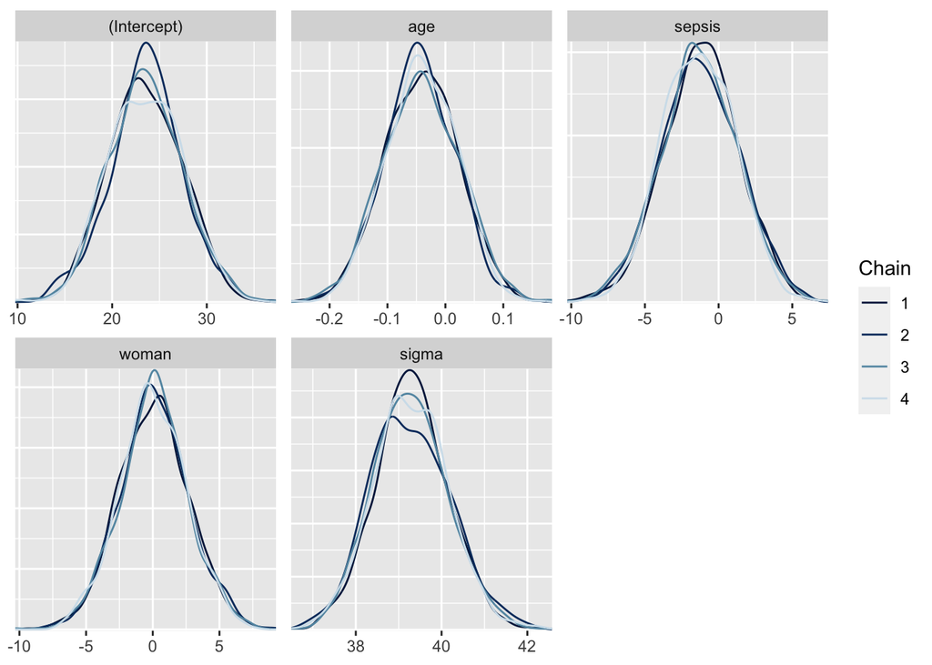

   ```r
   mcmc_dens_overlay(bayes_fit)
   ```

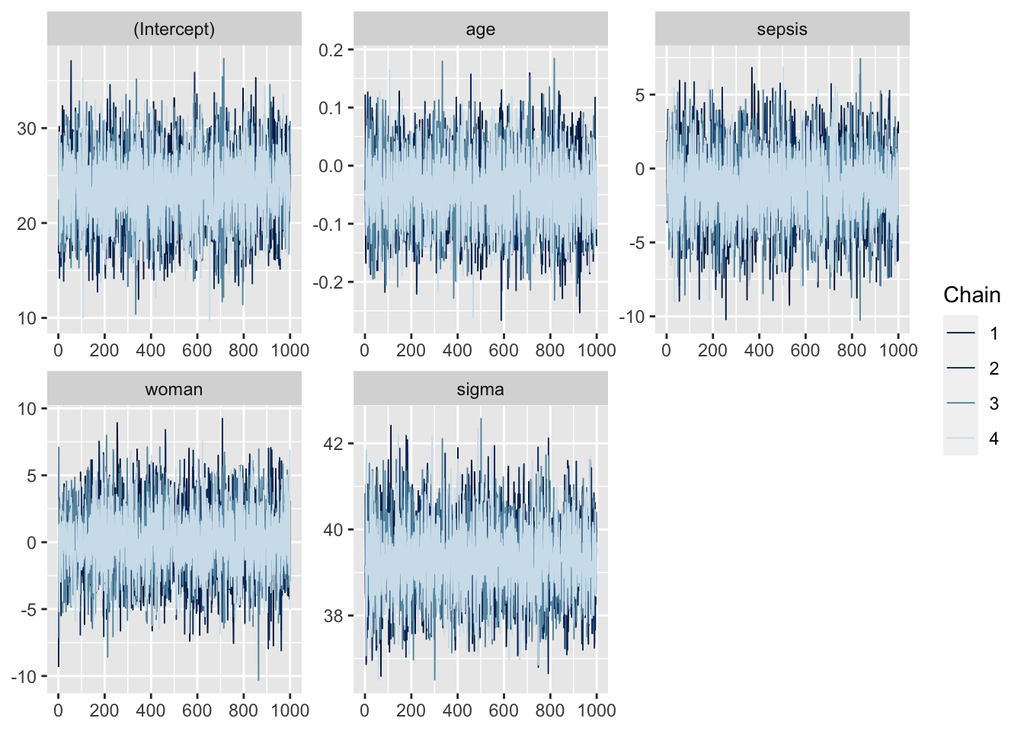

   ```r
   mcmc_trace(bayes_fit)
   ```

4. Use shinystan to investigate the model.

   ```r
   launch_shinystan(bayes_fit)
   ```

   ```r
   bayes_fit_more_longer <- stan_glm(
     icu_los ~ age + sepsis + woman,
     data = icu,
     iter = 8000,
     chains = 8,
     seed = 4131,
     refresh = 0
   )

   summary(bayes_fit_more_longer)
   ```

   ```
   ##
   ## Model Info:
   ##  function:     stan_glm
   ##  family:       gaussian [identity]
   ##  formula:      icu_los ~ age + sepsis + woman
   ##  algorithm:    sampling
   ##  sample:       32000 (posterior sample size)
   ##  priors:       see help('prior_summary')
   ##  observations: 998
   ##  predictors:   4
   ##
   ## Estimates:
   ##               mean   sd   10%   50%   90%
   ## (Intercept) 23.6    3.9 18.7  23.6  28.6
   ## age          0.0    0.1 -0.1   0.0   0.0
   ## sepsis      -1.2    2.6 -4.5  -1.2   2.1
   ## woman        0.0    2.6 -3.3   0.0   3.4
   ## sigma       39.3    0.9 38.2  39.3  40.4
   ##
   ## Fit Diagnostics:
   ##            mean   sd   10%   50%   90%
   ## mean_PPD 20.7    1.8 18.5  20.7  23.0
   ##
   ## The mean_ppd is the sample average posterior predictive distribution of the outcome variable (for details see help('summary.stanreg')).
   ##
   ## MCMC diagnostics
   ##               mcse Rhat n_eff
   ## (Intercept)   0.0  1.0  46903
   ## age           0.0  1.0  46806
   ## sepsis        0.0  1.0  43739
   ## woman         0.0  1.0  41971
   ## sigma         0.0  1.0  44268
   ## mean_PPD      0.0  1.0  36564
   ## log-posterior 0.0  1.0  13082
   ##
   ## For each parameter, mcse is Monte Carlo standard error, n_eff is a crude measure of effective sample size, and Rhat is the potential scale reduction factor on split chains (at convergence Rhat=1).
   ```

6. Look at the posterior distribution of the `sepsis` parameter. What is your conclusion about the effect of sepsis on ICU length of stay? What is the probability that the effect of sepsis is associated with shortened ICU-LOS? Shortening by more than 1 day?

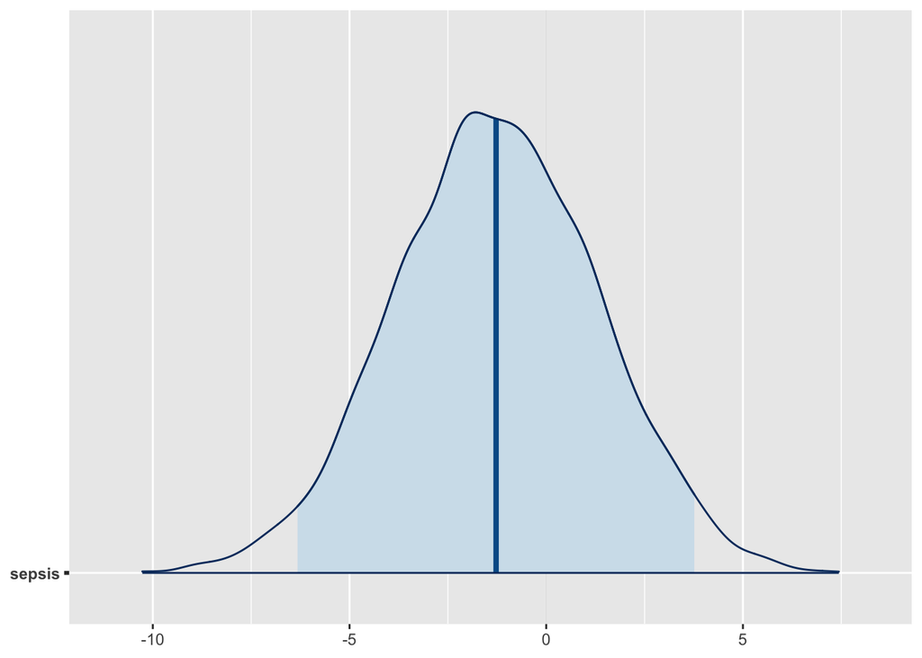

   ```r
   mcmc_areas(bayes_fit, pars = "sepsis", prob = 0.95)
   ```

   ```r
   mean(as.data.frame(bayes_fit)$sepsis < 0)
   ```

   ```
   ## [1] 0.68725
   ```

   ```r
   mean(as.data.frame(bayes_fit)$sepsis < -1)
   ```

   ```
   ## [1] 0.54175
   ```

   ```r
   mean(as.data.frame(bayes_fit)$sepsis < -2)
   ```

   ```
   ## [1] 0.39125
   ```

   ```r
   mean(as.data.frame(bayes_fit)$sepsis < -5)
   ```

   ```
   ## [1] 0.0715
   ```

7. How might you use a survey to devise an informative prior on the effect of age on ICU length of stay?

   ```r
   #' One could, for example, ask respondents to distribute 20 X's on a grid with
   #' how many days longer a patient would be expected to remain admitted for
   #' each decade they are older. Then, combine all those X's into one and fit
   #' a Normal distribution to it whose mean and sd would be the prior values.
   #'
   #' One respondents might submit this:
   #'
   #' ^
   #' |           X X X
   #' |         X X X X X
   #' |         X X X X X
   #' |       X X X X X X X
   #' |----------------------->
   ```

8. We can use leave-one-out-cross-validation (LOO) information criterion (IC) to see how well different models predict the outcome. These LOOICs can then be compared. Like other information criteria, lower is better. Importantly, the LOOIC comes with a standard error. Fit a model without the sepsis covariate and compare the LOOIC between the original and the reduced models.
   - Hint: see `?loo` and `?loo_compare`

   ```r
   bayes_fit_wo_sepsis <- stan_glm(
     icu_los ~ age + woman,
     data = icu,
     seed = 4131,
     refresh = 0
   )

   loo_fit <- loo(bayes_fit)
   loo_fit_wo_sepsis <- loo(bayes_fit_wo_sepsis)
   loo_compare(loo_fit, loo_fit_wo_sepsis)
   ```

   ```
   ##                     elpd_diff se_diff
   ## bayes_fit_wo_sepsis  0.0       0.0
   ## bayes_fit           -0.7       0.5
   ```

## E. Effect-size estimation in clinical trial

   Using an appropriate prior, estimate the effect size of obelixaban compared to standard of care.
   - Hint: recall that derived quantities, based on posterior parameter estimates, can be computed directly with the posterior samples of the parameters
   - Hint: effect-size metrics include risk ratio (RR), risk difference (RD) and number-needed-to-treat (NNT)
   - Hint: use what you learnt in exercises A6 and B1

   ```r
   find_beta_params(0.2, 0.05)
   ```

   ```
   ##   alpha beta       p2.5     p50.0     p97.5
   ## 1     3   13 0.04331201 0.1743207 0.4046027
   ```

   ```r
   post_estimates <- tibble(
     mortality_prop_control = rbeta(10000, 3 + 46, 13 + 161),
     mortality_prop_obelixaban = rbeta(10000, 3 + 35, 13 + 164),
     RR = mortality_prop_obelixaban / mortality_prop_control
   )
   quantile(post_estimates$RR, c(0.025, 0.5, 0.975))
   ```

   ```
   ##      2.5%       50%     97.5%
   ## 0.5460058 0.8038889 1.1755551
   ```

2. After helping your friend with their unadjusted effect-size estimation above, you return to your own results of the effect of miraculixaban against standard of care on 1-year mortality (same data as in section D).  
   Model the 1-year mortality risk using the four baseline covariates in the dataset (`treatment`, `age`, `woman` and `sepsis`) and default priors. What do you conclude about the conditional effects of miraculixaban on the 1-year mortality risk? Can you conclude anything about the effects of the other covariates?

   ```r
   mortality_fit <- stan_glm(
     dead_at_1y ~ treatment + age + woman + sepsis,
     data = icu,
     family = binomial,
     seed = 4131,
     refresh = 0 # suppress fitting progress output
   )

   summary(mortality_fit, probs = c(0.025, 0.5, 0.975))
   ```

   ```
   ##
   ## Model Info:
   ##  function:     stan_glm
   ##  family:       binomial [logit]
   ##  formula:      dead_at_1y ~ treatment + age + woman + sepsis
   ##  algorithm:    sampling
   ##  sample:       4000 (posterior sample size)
   ##  priors:       see help('prior_summary')
   ##  observations: 998
   ##  predictors:   5
   ##
   ## Estimates:
   ##               mean   sd    2.5%   50%   97.5%
   ## (Intercept) -43.3    4.1 -51.9  -43.2 -35.8
   ## treatment    -0.9    0.4  -1.8   -0.9   0.0
   ## age           0.7    0.1   0.6    0.7   0.9
   ## woman         0.0    0.4  -0.8    0.0   0.9
   ## sepsis        0.5    0.4  -0.3    0.5   1.4
   ##
   ## Fit Diagnostics:
   ##            mean   sd   2.5%   50%   97.5%
   ## mean_PPD 0.4    0.0  0.4    0.4   0.4
   ##
   ## The mean_ppd is the sample average posterior predictive distribution of the outcome variable (for details see help('summary.stanreg')).
   ##
   ## MCMC diagnostics
   ##               mcse Rhat n_eff
   ## (Intercept)   0.1  1.0  1737
   ## treatment     0.0  1.0  2886
   ## age           0.0  1.0  1753
   ## woman         0.0  1.0  2614
   ## sepsis        0.0  1.0  3110
   ## mean_PPD      0.0  1.0  3532
   ## log-posterior 0.0  1.0  1871
   ##
   ## For each parameter, mcse is Monte Carlo standard error, n_eff is a crude measure of effective sample size, and Rhat is the potential scale reduction factor on split chains (at convergence Rhat=1).
   ```

   ```r
   # Convergence diagnostics
   rhat(mortality_fit)
   ```

   ```
   ## (Intercept)   treatment         age       woman      sepsis
   ##   1.0036576   0.9997484   1.0035293   1.0003075   0.9997862
   ```

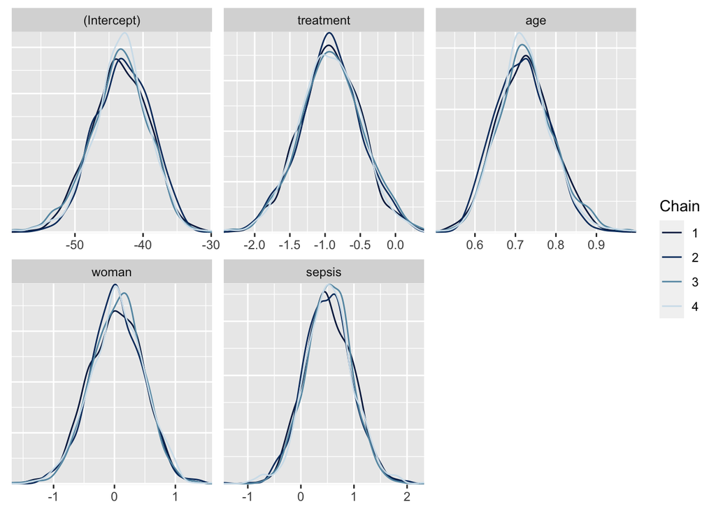

   ```r
   mcmc_dens_overlay(mortality_fit)
   ```

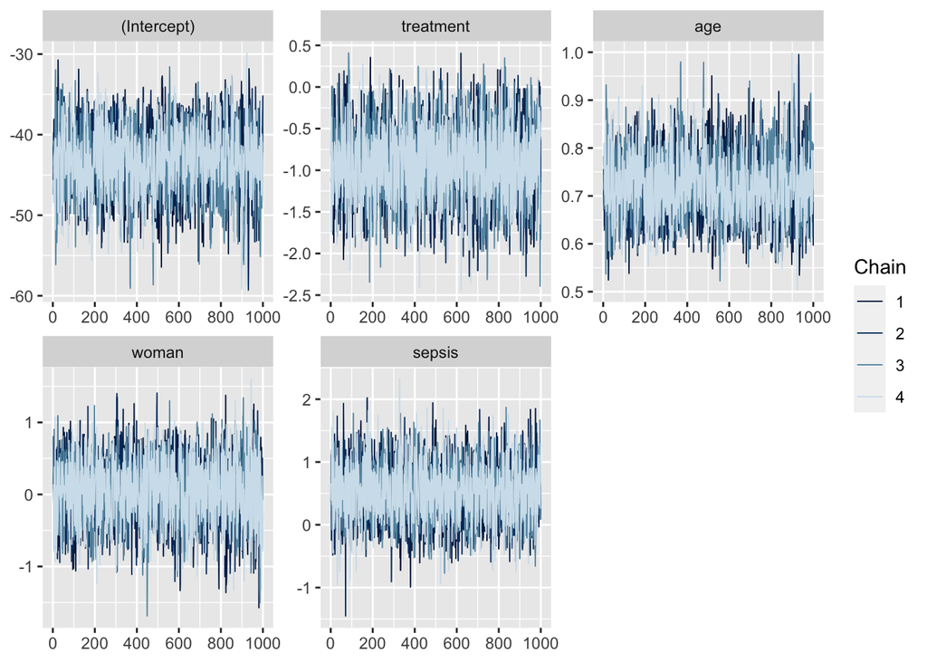

   ```r
   mcmc_trace(mortality_fit)
   ```

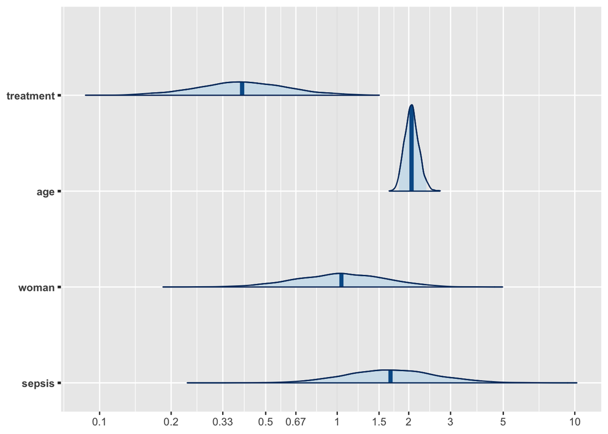

   ```r
   mcmc_areas(
     mortality_fit,
     point_est = "median",
     pars = vars(-"(Intercept)"),
     prob = 0.95
   ) +
     scale_x_continuous(
       breaks = log(c(0.1, 0.2, 0.33, 0.5, 0.67, 1, 1.5, 2, 3, 5, 10)),
       labels = exp
     )
   ```

3. Since you need to get your new drug approved by the authorities, you decide to use a somewhat skeptical prior on the treatment effect so that an estimated effect will convince even the grumpiest regulator. How could you devise such a skeptical prior for the effect of the treatment?
   - Hint: remember that coefficients in a logistic regression are log-OR’s and that the distribution of log-OR can be expressed in terms of an equivalent trial of a given size with a given event proportion.

   ```r
   r <- 0.35
   N <- 200
   (sigma <- sqrt(4/(1-r)/N + 4/r/N))
   ```

   ```
   ## [1] 0.2964997
   ```

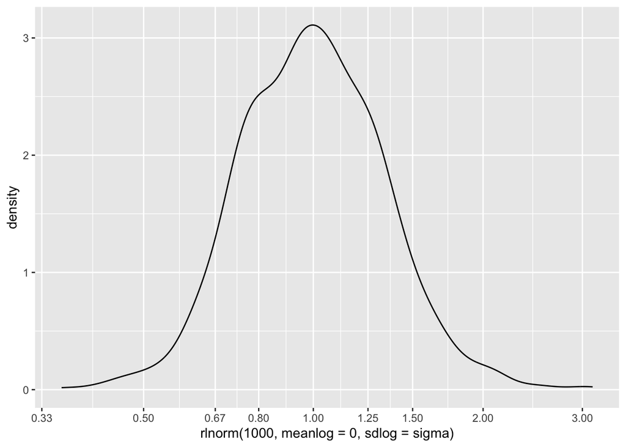

   ```r
   ggplot() +
     geom_density(aes(rlnorm(1000, meanlog = 0, sdlog = sigma))) +
     scale_x_log10(breaks = c(0.33, 0.5, 0.67, 0.8, 1, 1.25, 1.5, 2, 3))
   ```

4. Rerun the logistic regression with this new informative prior. What’s the impact on the (estimated) conditional treatment effect?

   ```r
   # Only difference is the scale of the first parameter
   priors <- normal(
     location = c(0, 0, 0, 0),
     scale = c(sigma, 2.5, 2.5, 2.5)
   )

   mortality_fit_skeptical <- stan_glm(
     dead_at_1y ~ treatment + age + woman + sepsis,
     data = icu,
     prior = priors,
     family = binomial,
     seed = 4131,
     refresh = 0 # suppress fitting progress output
   )

   summary(mortality_fit_skeptical, probs = c(0.025, 0.5, 0.975))
   ```

   ```
   ##
   ## Model Info:
   ##  function:     stan_glm
   ##  family:       binomial [logit]
   ##  formula:      dead_at_1y ~ treatment + age + woman + sepsis
   ##  algorithm:    sampling
   ##  sample:       4000 (posterior sample size)
   ##  priors:       see help('prior_summary')
   ##  observations: 998
   ##  predictors:   5
   ##
   ## Estimates:
   ##               mean   sd    2.5%   50%   97.5%
   ## (Intercept) -75.2    9.0 -93.8  -74.9 -58.4
   ## treatment    -0.3    0.3  -0.8   -0.3   0.2
   ## age           1.2    0.1   1.0    1.2   1.5
   ## woman         0.1    0.6  -1.0    0.1   1.2
   ## sepsis        1.3    0.6   0.1    1.3   2.5
   ##
   ## Fit Diagnostics:
   ##            mean   sd   2.5%   50%   97.5%
   ## mean_PPD 0.4    0.0  0.4    0.4   0.4
   ##
   ## The mean_ppd is the sample average posterior predictive distribution of the outcome variable (for details see help('summary.stanreg')).
   ##
   ## MCMC diagnostics
   ##               mcse Rhat n_eff
   ## (Intercept)   0.2  1.0  1969
   ## treatment     0.0  1.0  3317
   ## age           0.0  1.0  1991
   ## woman         0.0  1.0  3542
   ## sepsis        0.0  1.0  2901
   ## mean_PPD      0.0  1.0  4117
   ## log-posterior 0.0  1.0  1685
   ##
   ## For each parameter, mcse is Monte Carlo standard error, n_eff is a crude measure of effective sample size, and Rhat is the potential scale reduction factor on split chains (at convergence Rhat=1).
   ```

   ```r
   prior_summary(mortality_fit_skeptical)
   ```

   ```
   ## Priors for model 'mortality_fit_skeptical'
   ## ------
   ## Intercept (after predictors centered)
   ##  ~ normal(location = 0, scale = 2.5)
   ##
   ## Coefficients
   ##  ~ normal(location = [0,0,0,...], scale = [0.3,2.5,2.5,...])
   ## ------
   ## See help('prior_summary.stanreg') for more details
   ```

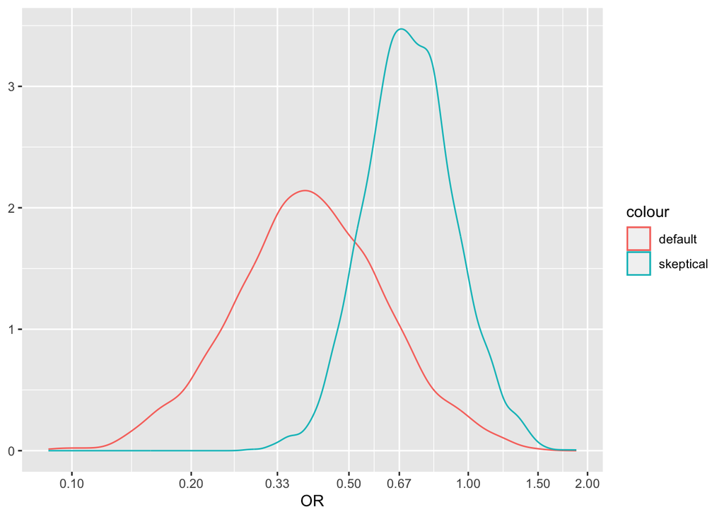

   ```r
   map(list(mortality_fit, mortality_fit_skeptical), as.data.frame) %>%
     map_dfc("treatment") %>%
     setNames(c("default", "skeptical")) %>%
     ggplot() +
       geom_density(aes(x = exp(default), colour = "default")) +
       geom_density(aes(x = exp(skeptical), colour = "skeptical")) +
       scale_x_log10(breaks = c(0.1, 0.2, 0.33, 0.5, 0.67, 1, 1.5, 2, 3, 5, 10)) +
       labs(x = "OR", y = NULL)
   ```

5. Compute average treatment effect using G-computation
   - Hint: predict the posterior probabilities of death for all patients if they had all received the miraculixaban and if they had all received standard of care Take a look at ?posterior_epred
   - Hint: here are two links for good introductions to G-computation: https://github.com/kathoffman/causal-inference-visual-guides/blob/master/visual-guides/G-Computation.pdf, https://doi.org/10.1093%2Fije%2Fdyw323

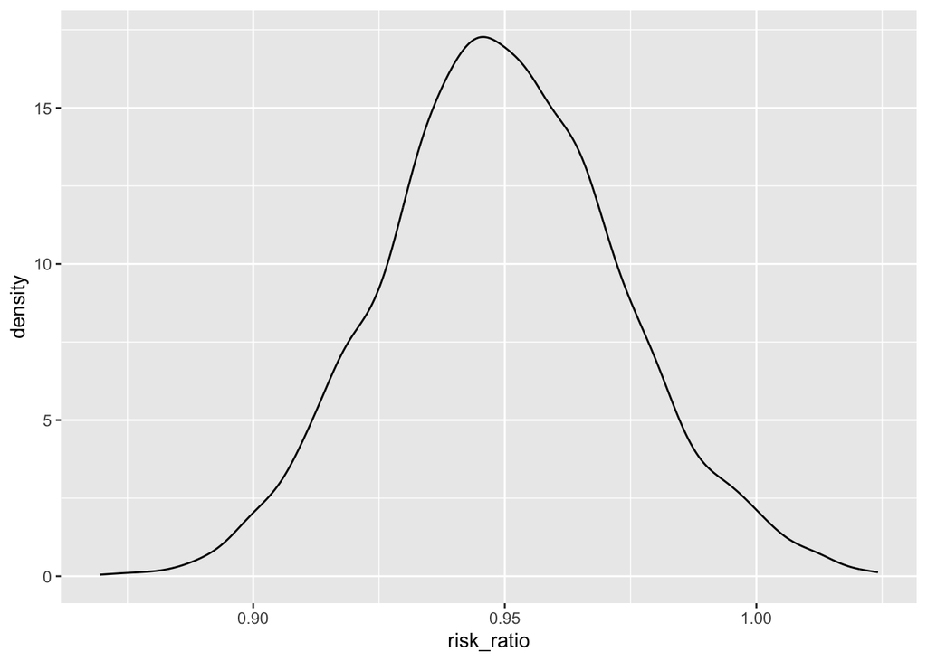

   ```r
   posterior_marginal_estimates <- map_dfc(
     c(miraculixaban = 1, control = 0),
     ~ rowMeans(posterior_epred(mortality_fit, mutate(icu, treatment = .)))
   ) %>%
     mutate(
       risk_ratio = miraculixaban / control,
       risk_diff = control - miraculixaban,
       NNT = 1/risk_diff
     )

   ggplot(posterior_marginal_estimates) +
     geom_density(aes(risk_ratio))
   ```

## F. Coding up linear regression in Stan

**NB! We didn’t make it here**

```stan
data {
  int<lower=1> N;
  vector[N] y;
  vector[N] x;
}

parameters {
  real intercept;
  real beta;
  real<lower=0> sigma; // note lower limit
}

model {
  // Prior distributions
  intercept ~ normal(0, 10);
  beta ~ normal(0, 10);
  sigma ~ cauchy(0, 2.5);

  // Likelihood
  y ~ normal(intercept + beta * x, sigma);
}
```

1. Modify this code to use all covariates and run the analysis
   - Hint: start by including and using the two numeric variables first.
   - Hint: then include the categorical variables as numeric variables (with values either 0 or 1). This works because the categorical predictors are binary.

## G. Resources

- Book - Richard McElreath: Statistical Rethinking https://xcelab.net/rm/statistical-rethinking/. Excellent introduction to Bayesian analysis. You really should start here.
- Article - Michael Betancourt: A Conceptual Introduction to Hamiltonian Monte Carlo https://arxiv.org/pdf/1701.02434.pdf. Excellent paper on HMC; it is a bit technical, but even if you skip the most technical parts and equations, there’s lots of learning in there.
- Article - Goligher et al.: Extracorporeal membrane oxygenation for severe acute respiratory distress syndrome and posterior probability of mortality benefit in a post hoc bayesian analysis of a randomized clinical trial https://doi.org/10.1001/jama.2018.14276
- Book - James V. Stone: Bayes’ Rule: a tutorial introduction to Bayesian analysis. A bit old but with a fun-ish take on things and not too much math.
- Book - Andrew Gelman et al.: Bayesian Dataz Analysis. The Bible but really not accessible and in no way the place to start for most people.